# Bootstrap inference in functional linear regression models with R

Hyemin Yeon[^1]

September 08, 2025

This is a brief introduction to the package `BTSinFLRM` based on the works by Yeon, Dai, and Nordman (2023, 2024, 2025) and Yeon and Kokoszka (2025). The package mainly contains four functions `RBinFLRM`, `PBinFLRM`, `WBinFLRM`, and `test2sofr`. which respectively implement the residual, paired, (multiplier) wild bootstrap methods for mean response inference and two-sample bootstrap tests. The first bootstrap is developed for functional linear regression models (FLRMs) under homoscedasticity, the next two methods are used for heteroscedastic FLRMs, and the last one is designed for two-sample testing framework. We illustrate how to use the package with simulated datasets.

# Bootstrap mean response inference

## Generating Gaussian curves

We simulate independent pairs $\{(X_i, Y_i)\}_{i=1}^n$ of functional regressors and scalar responses based on the following FLRM:
$$Y = \langle
\beta, X \rangle + \varepsilon.$$
The regressor curves $\{X_i\}_{i=1}^n$ are generated identically and independently from a Gaussian process. The construction is based on a truncated Karhuen–Loève expansion. The eigengap $\{\delta_j\}$ decays with polynomial decay rate $\delta_j = 2j^{-a}$ with $a=3.5$ and the eigenfunctions $\{\phi_j\}_{j=1}^J$ are chosen as Fourier functions. The slope function also has a polynomial decay rate $\beta_j = 2j^{-b}$ with $b=3.5$, and set $\beta = \sum_{j=1}^J \beta_j \phi_j$. Here, $J=15$ is used. Then, the regressor is constructed as $X \overset{\mathsf{d}}{=} \sum_{j=1}^J \sqrt{\gamma_j} \xi_j \phi_j$ where $\{\gamma_j\}$ are eigenvalues and $\xi_j \sim \mathsf{N}(0,1)$ are (normalized) functional principal component scores. With uniform errors $\varepsilon_i \sim \mathsf{U}(0,1)$, the responses are generated as $Y_i = \langle \beta, X_i \rangle + \varepsilon_i$.

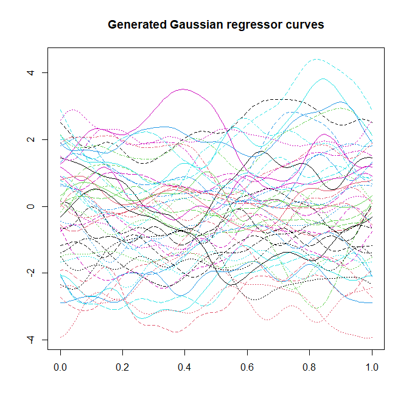

```r
# simulate the regressor curves from Karhunen–Loève expansion and responses
J=15

# eigenvalues
c=2; a=3.5; dt = c*(1:J)^(-a)
g1 = c*VGAM::zeta(a)
ga = c(g1, sapply(1:(J-1), function(j){g1 - sum(dt[1:j])}))

# eigenfunctions
tt = 100; tGrid = seq(0, 1, len=tt); J=15
phi= t(fda::fourier(tGrid, J))

# slope function
b=3.5; bj = c*((1:J)^(-b))*(rbinom(J, 1, 0.5)*2-1)
beta = c(bj %*% phi)

# generate (Gaussian) regressors and responses
n=50; n0=3
xi = matrix(rnorm(n*J), n, J); X = xi %*% (phi * sqrt(ga))
xi0 = matrix(rnorm(n0*J), n0, J); X0 = xi0 %*% (phi * sqrt(ga))
er = runif(n); Y = c(X %*% beta / tt + er)
```

## Bootstrap inference

For illustration of bootstrap inference, we choose $k_n = 3$, $h_n \in \{4,5,6\}$, $g_n= \{4,5\}$ for involved truncation parameters and $M=100$ for bootstrap resample size. The significance level is here $\alpha = 0.05$.

```r
# trunction parameters
kn_vec = c(3); hn_vec = c(4,5,6); gn_vec = c(4,5)

# residual bootstrap
M_bts=100

library(BTSinFLRM)
```

[figure not shown]

### Residual bootstrap

This section describes inference by CLT and residual bootstrap under homoscedasticity (Yeon, Dai, and Nordman 2023).

```r
resRB = RBinFLRM(X, Y, X0, tGrid, kn_vec, hn_vec, gn_vec, M_bts)
```

`resRB$CLT` provides the confidence and prediction intervals based on central limit theorem (Yeon, Dai, and Nordman 2023) with a five dimensional array. Here, the truncation parameter $k_n$ involves estimation of the error variance $\sigma_\varepsilon^2$ with estimator $\hat{\sigma}_\varepsilon^2 \equiv n^{-1} \sum_{i=1}^n (Y_i - \langle \hat{\beta}_{k_n}, X_i \rangle)^2$.

```r
resRB$CLT
```

[output not shown]

`resRB$RB` provides different intervals based on residual bootstrap (Yeon, Dai, and Nordman 2023). It is a list with three dimension where each dimension corresponds to different combinations of tuning parameters $(k_n, h_n, g_n)$. Each list contains a three dimensional array where the last dimension represent different types of intervals:

- Intervals for a truncated projection $\langle \Pi_{h_n} \beta, X_0 \rangle$, the projection $\langle \beta, X_0 \rangle$, and the predicted response $Y_0$.
- Individual and simultaneous intervals.
  - Symmetrized and unsymmetrized individual intervals
  - Studentized and non-studentized simultaneous intervals.

```r
resRB$RB
```

```
## , , gn=4
##
##      hn=4       hn=5       hn=6
## kn=3 numeric,72 numeric,72 numeric,72
##
## , , gn=5
##
##      hn=4       hn=5       hn=6
## kn=3 numeric,72 numeric,72 numeric,72
```

```r
# Access a component of list:
resRB$RB[["kn=3", "hn=5", "gn=4"]]
```

```
## , , ICI_trunc_unsym
##
##           lower      upper
## X0_1 -0.4966601 -0.1768345
## X0_2  4.2869713  4.7151296
## X0_3 -5.0554060 -4.6913439
##
## , , ICI_unsym
##
##           lower      upper
## X0_1 -0.4966601 -0.1768345
## X0_2  4.2869713  4.7151296
## X0_3 -5.0554060 -4.6913439
##
## , , IPI_unsym
##
##           lower      upper
## X0_1 -0.7882234  0.1668649
## X0_2  4.0467964  5.1029221
## X0_3 -5.3617397 -4.3466732
##
## , , ICI_trunc_sym
##
##           lower      upper
## X0_1 -0.5148742 -0.1838461
## X0_2  4.1924428  4.7005536
## X0_3 -5.0432965 -4.5291140
##
## , , ICI_sym
##
##           lower      upper
## X0_1 -0.5148742 -0.1838461
## X0_2  4.1924428  4.7005536
## X0_3 -5.0432965 -4.5291140
##
## , , IPI_sym
##
##           lower     upper
## X0_1 -0.8383743  0.139654
## X0_2  3.8357608  5.057236
```

[output cut: 28 more lines]

```
## X0_3 -5.1155774 -4.45683315
##
## , , SCI_std
##
##           lower       upper
## X0_1 -0.6662434 -0.03247692
## X0_2  4.0832782  4.80971823
## X0_3 -5.1155774 -4.45683315
##
## , , SPI_std
##
##           lower     upper
## X0_1  -5.649114 4.9503936
## X0_2  -0.948613 9.8416094
## X0_3 -10.110544 0.5381332
```

## Paired bootstrap

This section describes inference by CLT and paired bootstrap under heteroscedasticity (Yeon, Dai, and Nordman 2024).

```r
resPB = PBinFLRM(X, Y, X0, tGrid, kn_vec, hn_vec, gn_vec, M_bts)
```

`resPB$CLT` provides the confidence intervals based on central limit theorem (Yeon, Dai, and Nordman 2024) with a four dimensional array. Here, the truncation parameter $k_n$ is used to compute the estimated scaling $\hat{s}_{h_n}(X_{0,l})$ based on the observed samples.

```r
resPB$CLT
```

```
## , , X0_1, kn=3
##
##           lower      upper
## hn=4 -0.4717471 -0.1439869
## hn=5 -0.5170669 -0.1816534
## hn=6 -0.5034834 -0.1738480
##
## , , X0_2, kn=3
##
##         lower    upper
## hn=4 4.248632 4.668791
## hn=5 4.236072 4.656925
## hn=6 4.254400 4.700686
##
## , , X0_3, kn=3
##
##          lower     upper
## hn=4 -5.018359 -4.656345
## hn=5 -4.973538 -4.598872
## hn=6 -4.979371 -4.612034
```

`resPB$PBintervals` provides different intervals based on paired bootstrap proposed by Yeon, Dai, and Nordman (2024). It is a list with three dimension where each dimension corresponds to different combinations of tuning parameters $(k_n, h_n, g_n)$ as `resRB$RB` provides above. Each list contains a four dimensional array where the last two dimensions represent different types of intervals:

- Intervals for a truncated projection $\langle \Pi_{h_n} \beta, X_0 \rangle$ and the untruncated projection $\langle \beta, X_0 \rangle$.
- Individual and simultaneous intervals denoted as `II` and `SI` respectively.
  - Symmetrized and unsymmetrized individual intervals approximated by either non-studentized or studentized bootstrap estimators.
  - Studentized and non-studentized simultaneous intervals.

For obtaining studentized simultaneous intervals, two different scaling terms can be constructed when we compute the bootstrap statistics. One is the estimated scaling $\hat{s}_{h_n}(X_{0,l})$ from the observed samples (denoted as `SI_std1`) while the other is computed as $\hat{s}^*_{h_n}(X_{0,l})$ from the bootstrap resamples (denoted as `SI_std2`).

```r
resPB$PBintervals
```

```
## , , gn=4
##
##      hn=4       hn=5       hn=6
## kn=3 numeric,84 numeric,84 numeric,84
##
## , , gn=5
##
##      hn=4       hn=5       hn=6
## kn=3 numeric,84 numeric,84 numeric,84
```

```r
# Access a component of list:
resPB$PBintervals[["kn=3", "hn=5", "gn=4"]]
```

```
## , , trunc, II_unsym/nonstd
##
##          lower      upper
## X0_1 -1.115755  0.3510891
## X0_2  3.696644  5.1796315
## X0_3 -5.771882 -4.1507118
##
## , , untrunc, II_unsym/nonstd
##
##          lower      upper
## X0_1 -1.115755  0.3510891
## X0_2  3.696644  5.1796315
## X0_3 -5.771882 -4.1507118
##
## , , trunc, II_sym/nonstd
##
##          lower      upper
## X0_1 -1.111320  0.4125998
## X0_2  3.705108  5.1878888
## X0_3 -5.574865 -3.9975456
##
## , , untrunc, II_sym/nonstd
##
##          lower      upper
## X0_1 -1.111320  0.4125998
## X0_2  3.705108  5.1878888
## X0_3 -5.574865 -3.9975456
##
## , , trunc, II_unsym/std
##
##          lower      upper
## X0_1 -1.286378  0.2581361
## X0_2  3.814952  5.2097526
## X0_3 -6.064402 -4.2905837
##
## , , untrunc, II_unsym/std
##
##          lower      upper
## X0_1 -1.286378  0.2581361
## X0_2  3.814952  5.2097526
```

[output cut: 42 more lines]

```
## X0_3 -6.132413 -3.4399972
##
## , , trunc, SI_std2
##
##          lower     upper
## X0_1 -1.980875  1.282155
## X0_2  2.399390  6.493607
## X0_3 -6.608651 -2.963759
##
## , , untrunc, SI_std2
##
##          lower     upper
## X0_1 -1.980875  1.282155
## X0_2  2.399390  6.493607
## X0_3 -6.608651 -2.963759
```

`resPB$PBpvalues` contains the p-values from the bootstrap testing of whether the projection of the slope function $\beta$ onto the space spanned by the new regressors $\mathcal{X}_0 \equiv \{X_{0,l}\}_{l=1}^L$ based on the testing procedure described in Section 3 of Yeon, Dai, and Nordman (2024). The null hypothesis $H_0$ is represented as $\Pi_{\mathcal{X}_0} \beta = 0$ where $\Pi_{\mathcal{X}_0}$ denotes the projection operator onto the space spanned by the new regressors $\mathcal{X}_0 \equiv \{X_{0,l}\}_{l=1}^L$. This gives a list with three dimension where each dimension corresponds to different combinations of tuning parameters $(k_n, h_n, g_n)$. Each dimension contains the p-values from different test statistics:

- The statistics either with or without studentization. The bootstrap statistics can be studentized by the estimated scaling terms from either samples or bootstrap resamples.
- $L^2$ or maximum type statistics.
- The test statistics are computed when either enforcing the null $H_0: \Pi_{\mathcal{X}_0} \beta = 0$ or not, which are respectively denoted as `tilde` and `hat`.

```r
resPB$PBpvalues
```

```
## , , gn=4
##
##      hn=4       hn=5       hn=6
## kn=3 numeric,12 numeric,12 numeric,12
##
## , , gn=5
##
##      hn=4       hn=5       hn=6
## kn=3 numeric,12 numeric,12 numeric,12
```

```r
# Access a component of list:
resPB$PBpvalues[["kn=3", "hn=5", "gn=4"]]
```

```
## , , hat
##
##        L2 max
## nonstd  0   0
## std1    0   0
## std2    0   0
##
## , , tilde
##
##        L2 max
## nonstd  0   0
## std1    0   0
## std2    0   0
```

## Wild bootstrap

This section describes inference by multiplier wild bootstrap under heteroscedasticity (Yeon, Dai, and Nordman 2025). The results of `WBinFLRM` exhibit the same structure as the ones of `PBinFLRM`; the descriptions are hence omitted.

```r
resWB = WBinFLRM(X, Y, X0, tGrid, kn_vec, hn_vec, gn_vec, M_bts, multiplier="normal")
```

One notable difference is that users can choose multipliers used in `WBinFLRM` by sepcifying `multiplier` option. Three types of multipliers can be considered: two-point distribution with $\mathsf{P}(W_i = -(\sqrt{5}-1)/2) = (\sqrt{5}+1) / (2\sqrt{5}) = 1-\mathsf{P}(W_i = (\sqrt{5}+1)/2)$, the standard normal distribution with $W_i \sim \mathsf{N}(0,1)$, and the distribution of $W_i = V_i/2+(V_i^2-1)/2$ for independent standard normal variables $\{V_i\}_{i=1}^n$, which gives the third moment one $\mathsf{E}^*[W_i^3]=1$. These respectively correspond to `multiplier="bin"`, `multiplier="normal"`, and `multiplier="HM"`, where the second type is chosen in this example.

```r
resWB$WBintervals
```

```
## , , gn=4
##
##      hn=4       hn=5       hn=6
## kn=3 numeric,84 numeric,84 numeric,84
##
## , , gn=5
##
##      hn=4       hn=5       hn=6
## kn=3 numeric,84 numeric,84 numeric,84
```

```r
# Access a component of list:
resWB$WBintervals[["kn=3", "hn=5", "gn=4"]]
```

```
## , , trunc, II_unsym/nonstd
##
##           lower       upper
## X0_1 -0.6890739  0.06007192
## X0_2  4.1125344  4.85687267
## X0_3 -5.2222905 -4.46948746
##
## , , untrunc, II_unsym/nonstd
##
##           lower       upper
## X0_1 -0.6890739  0.06007192
## X0_2  4.1125344  4.85687267
## X0_3 -5.2222905 -4.46948746
##
## , , trunc, II_sym/nonstd
##
##           lower       upper
## X0_1 -0.7467121  0.04799177
## X0_2  4.0412652  4.85173125
## X0_3 -5.1620576 -4.41035287
##
## , , untrunc, II_sym/nonstd
##
##           lower       upper
## X0_1 -0.7467121  0.04799177
## X0_2  4.0412652  4.85173125
## X0_3 -5.1620576 -4.41035287
##
## , , trunc, II_unsym/std
##
##           lower      upper
## X0_1 -0.5212414 -0.1460589
## X0_2  4.2913761  4.6665511
## X0_3 -4.9850092 -4.6493563
##
## , , untrunc, II_unsym/std
##
##           lower      upper
## X0_1 -0.5212414 -0.1460589
## X0_2  4.2913761  4.6665511
```

[output cut: 42 more lines]

```
## X0_3 -5.394091 -4.1783195
##
## , , trunc, SI_std2
##
##           lower       upper
## X0_1 -0.6436257 -0.05509457
## X0_2  4.0772749  4.81572156
## X0_3 -5.1149078 -4.45750275
##
## , , untrunc, SI_std2
##
##           lower       upper
## X0_1 -0.6436257 -0.05509457
## X0_2  4.0772749  4.81572156
## X0_3 -5.1149078 -4.45750275
```

Although Yeon, Dai, and Nordman (2025) does not contain the hypothesis tests based on the wild bootstrap, one might mimic the procedure proposed by Yeon, Dai, and Nordman (2024) in the wild bootstrap procedure. The result `resWB$WBpvalues` below contains the p-values from this bootstrap testing procedure.

```r
resWB$WBpvalues
```

```
## , , gn=4
##
##      hn=4       hn=5       hn=6
## kn=3 numeric,12 numeric,12 numeric,12
##
## , , gn=5
##
##      hn=4       hn=5       hn=6
## kn=3 numeric,12 numeric,12 numeric,12
```

```r
# Access a component of list:
resWB$WBpvalues[["kn=3", "hn=5", "gn=4"]]
```

```
## , , hat
##
##        L2 max
## nonstd  0   0
## std1    0   0
## std2    0   0
##
## , , tilde
##
##        L2 max
## nonstd  0   0
## std1    0   0
## std2    0   0
```

# Bootstrap two-sample tests for scalar-on-function regression

This chapter describes two-sample inference for scalar-on-function regression proposed by Yeon and Kokoszka (2025). We now consider the following two-sample framework:
$$Y_{ki} = \langle \beta_k, X_{ki} \rangle +
\varepsilon_{ki}, \quad i=1,\dots,n_k, \quad k=1,2$$
We are interested in testing whether two slope functions $\beta_1$ and $\beta_2$ are equal, i.e., the null hypothesis is $H_0:\beta_1 = \beta_2$. In this chapter, the data will be generated in a similar way to the previous chapter with $J = 20$. To consider more complex scenarios with unequal covariance operators of the regressors $\{X_{1i}\}_{i=1}^{n_1}$ and $\{X_{2i}\}_{i=1}^{n_2}$ from the two gruops, we will define two distinct eigenvalue dacay rates $a \in \{2.5, 5\}$ and three different orthonormal systems based on trigonometric, monimial, and Chebyshev functions. The slope functions can differ linearly or orthogonally, the sample sizes are equal as $n_1=25=n_2$, the error variance is 1, the truncation levels are considered among $H = \{1, \dots, 20\}$, and the bootstrap resample size is again 100.

```r
Jtrue=20 # The number of basis elements used in data generation

# create eigenvalues based on polynomial eigengaps with rate a
ev_poly = function(a, c, J){
  dt = c*(1:J)^(-a)
  ld1 = c*VGAM::zeta(a)
  ld = c(ld1, sapply(1:(J-1), function(j){ld1 - sum(dt[1:j])}))
  return(ld)
}

# eigenvalues for unequal cov
ga_rough  = ev_poly(2.5, 2, Jtrue) # a=2.5
ga_smooth = ev_poly(5, 2, Jtrue)   # a=5

# Equi-spaced time grid points in [0,1]
tt = 50; tGrid_ttt = seq(0, 1, len=tt+1);
tGrid = tGrid_ttt[1:tt]
diffrange = diff(tGrid)[1] + diff(range(tGrid)) # when using left points
scal = diffrange / tt   # scaling factor for integration

# basis functions for beta, and for X under equal cov
phi_base = t(fda::fourier(tGrid_ttt, 2*Jtrue))[-1,1:tt]  # trigonometric functions
phi = phi_base[1:Jtrue,]

# basis functions for X under unequal cov
mono = t(sapply(1:Jtrue, function(j)tGrid^j))
phi_mono = BTSinFLRM:::orthoL2Equidense(mono, tGrid)
cheb = t(sapply(1:Jtrue, function(j)pracma::chebPoly(j, 2*tGrid-1)))
phi_cheb = BTSinFLRM:::orthoL2Equidense(cheb, tGrid)

# Determine the second order structures
eveq = TRUE # eigenvalues are equal?
efeq = TRUE # eigenfunctions are equal?
if(eveq){  # equal eigenvalues
  ga1 = ga2 = ga_rough
}else{  # unequal eigenvalues
  ga1 = ga_smooth; ga2 = ga_rough
}
if(efeq){  # equal eigenfunctions
  phi1 = phi; phi2 = phi
}else{  # unequal eigenfunctions
  phi1 = phi_mono; phi2 = phi_cheb
}
```

```r
# Slope functions
b=2; Wbetaj = rbinom(Jtrue, 1, 0.5)*2-1
bj = 3*((1:Jtrue)^(-b))*Wbetaj; beta = c(bj %*% phi)

beta_arr = array(0, dim=c(2, tt, 2), dimnames=list(
  1:2, NULL, paste0("type", 0:1)
))
# 0: linear difference
beta_arr[1,,"type0"] = 1*beta
beta_arr[2,,"type0"] = 2*beta

# 1: orthogonal difference
beta_arr[1,,"type1"] = c(bj[1:5] %*% phi[1:5,])
beta_arr[2,,"type1"] = c(bj[1:5] %*% phi[6:10,])

beta1 = beta_arr[1,,"type0"]
c_alter = 0.5 # strength of alternative
beta2 = (1-c_alter)*beta1 + c_alter*beta_arr[2,,"type0"]

# Other factors

n=50; n1 = n2 = n/2      # n1=48; n2=52
group = c(rep(1,n1), rep(0,n2))
idx1 = as.logical(group); idx2 = !idx1
xi_type=0 # Gaussian random function
er_type=0 # Normal error
sig_sq =1 # the error variance

# # # # # # # # # # #
# generate data

# FPC scores
Wj = matrix(rnorm(n*Jtrue), n, Jtrue)
if(xi_type==2){
  xi = rexp(n) - 1 # normal*exp FPC scores
}else if(xi_type==1){
  xi = rnorm(n) # normal*normal FPC scores
}else{
  xi = rep(1,n) # independent FPC scores
}

# # unequal FPC scores
# xi1 = rnorm(n1); xi2 = rexp(n2) - 1
# xi[idx1,] = xi1; xi[idx2,] = xi2

Xfpc = matrix(0, n, Jtrue)
Xfpc[idx1,] = t(sqrt(ga1) * t(xi[idx1]*Wj[idx1,]))
Xfpc[idx2,] = t(sqrt(ga2) * t(xi[idx2]*Wj[idx2,]))

# regerssor functions

X = matrix(0, n, tt)
X[idx1,] = Xfpc[idx1,] %*% phi1
X[idx2,] = Xfpc[idx2,] %*% phi2

X1 = X[idx1,]; X2 = X[idx2,]

X1beta1 = c(X1 %*% beta1 * scal)
X2beta2 = c(X2 %*% beta2 * scal)

if(er_type==1){   # centered exponential error
  par_scale = sqrt(sig_sq)
  er = rexp(n, 1/par_scale) - par_scale
}else{     # normal error
  er = rnorm(n, 0,sd=sqrt(sig_sq))
}

# response variables
Y1 = X1beta1 + er[idx1]
Y2 = X2beta2 + er[idx2]
Y = rep(0,n); Y[idx1] = Y1; Y[idx2] = Y2

# Bootstrap tests for two-sample scalar-on-function regression (not run)
res2sofr = test2sofr(Y, X, tGrid, group, B=100)
```

The results `res2sofr$res_hEach` include the test statistics based on pooled (PD) and simultaneous (SD) diagonalization approaches, the corresponding p-values using both asymptotic and bootstrap approximation, and different typs of variance explained (VE) for each truncation level in $H$. The results `res2sofr$res_hSel` include both PD and SD statistics, the corresponding p-values, and the selected truncation levels among $H$, when the truncation level is selected by using some VE with threshold $\rho \in (0,1)$. Some example of these results are given below.

```r
res2sofr$res_hSel$pval
```

```
## , , FVE_PD
##
##       rho=0.75 rho=0.8 rho=0.85 rho=0.9 rho=0.95 rho=0.99 rho=0.995 rho=0.999
## asymp        0       0        0       0        0     0.00      0.00      0.00
## BTS          0       0        0       0        0     0.02      0.12      0.36
## BTSH0        0       0        0       0        0     0.02      0.10      0.36
##
## , , RVE_PD
##
##           rho=0.75      rho=0.8 rho=0.85 rho=0.9 rho=0.95 rho=0.99 rho=0.995
## asymp 5.195844e-14 5.195844e-14        0       0        0        0         0
## BTS   0.000000e+00 0.000000e+00        0       0        0        0         0
## BTSH0 0.000000e+00 0.000000e+00        0       0        0        0         0
##       rho=0.999
## asymp      0.00
## BTS        0.14
## BTSH0      0.20
##
## , , RVE_SD
##
##       rho=0.75 rho=0.8 rho=0.85 rho=0.9 rho=0.95 rho=0.99 rho=0.995 rho=0.999
## asymp        0       0        0       0        0        0         0         0
## BTS          0       0        0       0        0        0         0         0
## BTSH0        0       0        0       0        0        0         0         0
```

## References

Yeon, Hyemin, Xiongtao Dai, and Daniel J Nordman. 2023. “Bootstrap inference in functional linear regression models with scalar response.” *Bernoulli* 29 (4): 2599–2626. https://doi.org/10.3150/22-BEJ1554.

———. 2024. “Bootstrap Inference in Functional Linear Regression Models with Scalar Response Under Heteroscedasticity.” *Electronic Journal of Statistics* 18 (2): 3590–3627.

———. 2025. “Wild bootstrap for mean response inference in functional linear regression models.” *Submitted*.

Yeon, Hyemin, and Piotr Kokoszka. 2025. “Bootstrap two-sample tests for scalar-on-function regression.” *Submitted*.

[^1]: https://sites.google.com/view/hyeminyeon/